# Regresie liniara clasica

Cozma Laura-Elena, Iamandii Ana-Maria, Manolache Andrei

# Cuprins

#### I. Regresia liniara simpla

#### II. Regresia liniara multipla

#### III. Selectarea și cercetarea modelelor de regresii liniare

# I. Regresia liniara simpla

Regresia liniara simpla este o metoda statistica prin care se descrie **relatia dintre doua variabile**:

- Variabila **independenta**, de obicei notata cu X, numita **variabila explicativa** sau **predictor**
- Variabila continua **dependenta** rezultata, notata cu Y, numita **variabila raspuns**.

# 1. Definirea modelului

$$Y|X= \beta_0 + \beta_1X + \epsilon$$

#### Parametrii modelului:

- X - **predictorul**
- Y - **variabila dependenta**
- $\beta_0$ - **interceptorul**
- $\beta_1$ - **panta**
- $\epsilon$ - **reziduul**

# 2. Implementarea modelului de regresie liniara

- Setul de date *survey* din *MASS package*

```
##      Sex Wr.Hnd NW.Hnd W.Hnd    Fold Pulse    Clap Exer Smoke Height      M.I
## 1 Female   18.5   18.0 Right  R on L    92    Left Some Never 173.00   Metric
## 2   Male   19.5   20.5  Left  R on L   104    Left None Regul 177.80 Imperial
## 3   Male   18.0   13.3 Right  L on R    87 Neither None Occas     NA     <NA>
## 4   Male   18.8   18.9 Right  R on L    NA Neither None Never 160.00   Metric
## 5   Male   20.0   20.0 Right Neither    35   Right Some Never 165.00   Metric
## 6 Female   18.0   17.7 Right  L on R    64   Right Some Never 172.72 Imperial
##      Age
## 1 18.250
## 2 17.583
## 3 16.917
## 4 20.333
## 5 23.667
## 6 21.000
```

- Reprezentarea grafica a datelor

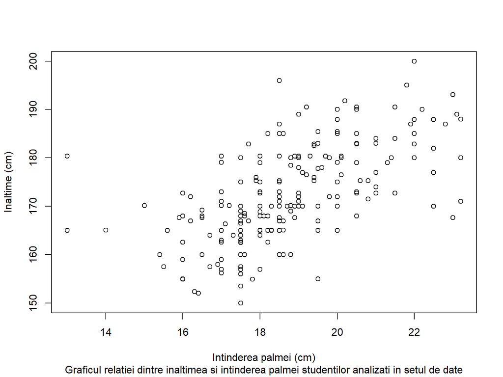

# 3. Estimarea coeficientilor

- Estimarea parametrilor se face folosind functia **lm**

```r
survfit <- lm(Height~Wr.Hnd,data=survey)
survfit
```

```
##
## Call:
## lm(formula = Height ~ Wr.Hnd, data = survey)
##
## Coefficients:
## (Intercept)       Wr.Hnd
##     113.954        3.117
```

- Ecuatia modelului estimat

$$\hat{y} = 113.954 + 3.117x$$

- Graficul observatiilor din setul de date, impreuna cu dreapta determinata de ecuatia modelului de regresie si reziduurile

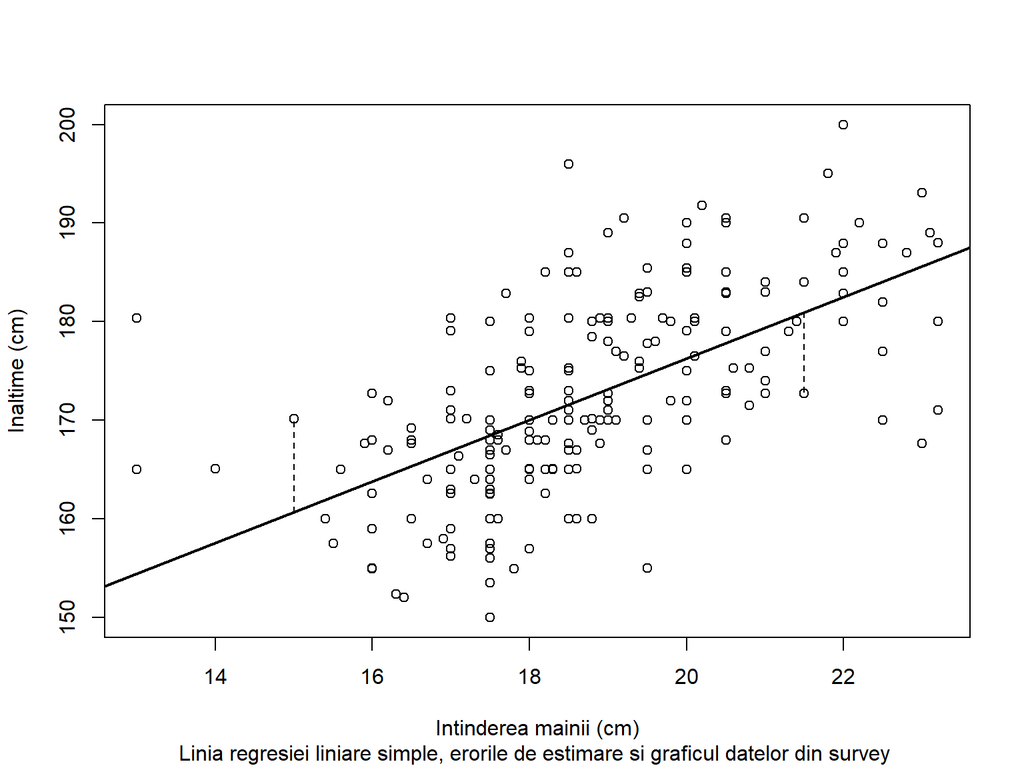

# 4. Inferenta statistica

- Problema: Exista o dovada statistica care sa sustina prezenta unei relatii intre predictor si raspuns?
- Solutie: metoda **summary**

```r
summary(survfit)
```

```
##
## Call:
## lm(formula = Height ~ Wr.Hnd, data = survey)
##
## Residuals:
##      Min       1Q   Median       3Q      Max
## -19.7276  -5.0706  -0.8269   4.9473  25.8704
##
## Coefficients:
##             Estimate Std. Error t value Pr(>|t|)
## (Intercept) 113.9536     5.4416   20.94   <2e-16 ***
## Wr.Hnd        3.1166     0.2888   10.79   <2e-16 ***
## ---
## Signif. codes:  0 '***' 0.001 '**' 0.01 '*' 0.05 '.' 0.1 ' ' 1
##
## Residual standard error: 7.909 on 206 degrees of freedom
##   (29 observations deleted due to missingness)
## Multiple R-squared:  0.3612, Adjusted R-squared:  0.3581
## F-statistic: 116.5 on 1 and 206 DF,  p-value: < 2.2e-16
```

# 5. Predictia valorilor

Calculam predictiile inaltimilor pentru intinderea palmei de 14.5 cm, respectiv 24 cm.

```
##        fit      lwr      upr
## 1 159.1446 156.4956 161.7936
## 2 188.7524 185.5726 191.9323
```

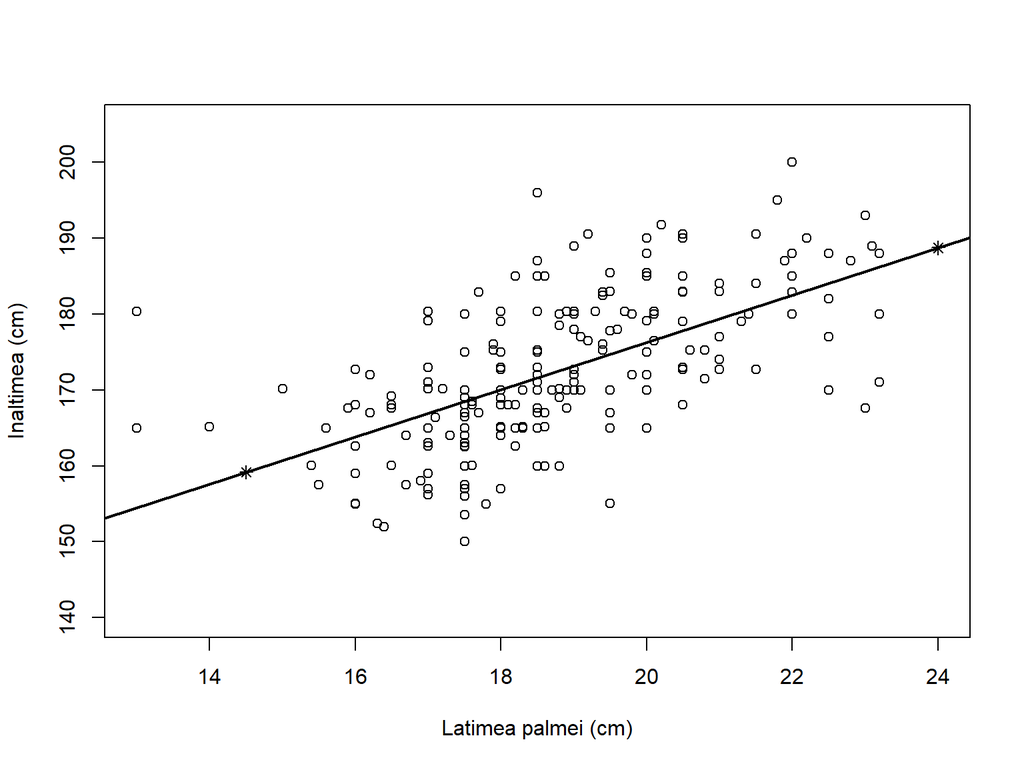

### **Interpolarea si Extrapolarea**

**Interpolare** - cand valoarea x a predictorului se afla in intervalul datelor observate

**Extrapolare** - x este in exteriorul intervalului

x = 14.5 - interpolare

y = 24 - extrapolare

# 6. Regresie liniara simpla folosind un predictor categoric

Variabila categorica este o variabila care poate lua un numar fix de posibile valori, fiecare reprezentand un grup sau o categorie.

### Variabile binare: k = 2

- Ecuatia modelului de regresie

$$Y|X=\beta_0 + \beta_1X + \epsilon$$

- $\beta_0$ - **baseline** sau **referinta** $X = 0 => Y = \beta_0 + \epsilon$
- $\beta_1$ - **efectul aditiv** $X = 1 => Y = \beta_0 + \beta_1 + \epsilon$

# 7. **Reprezentare grafica**

Se folosesc variabilele Height si Sex din setul de date **survey**

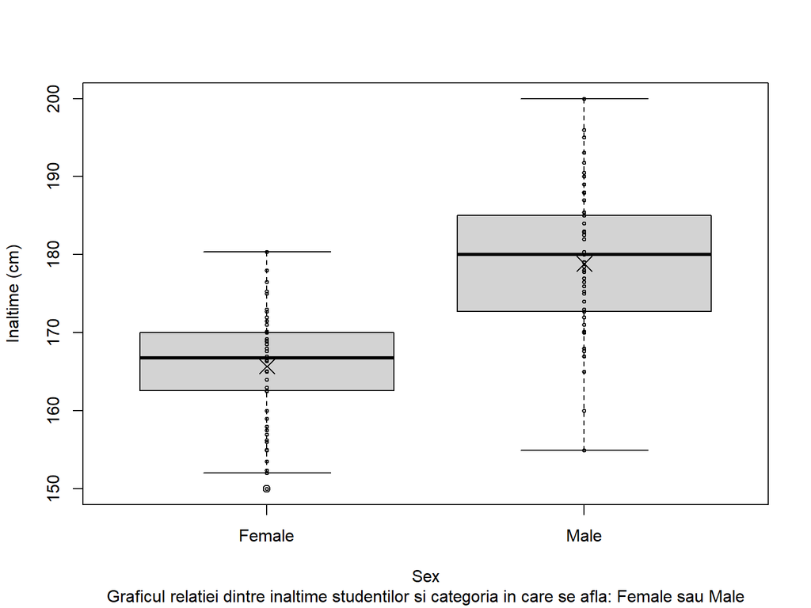

# 8. **Estimarea coeficientilor**

Se face cu ajutorul functiei **lm**:

```r
survfit2 <- lm(Height~Sex,data=survey)
summary(survfit2)
```

```
##
## Call:
## lm(formula = Height ~ Sex, data = survey)
##
## Residuals:
##     Min      1Q  Median      3Q     Max
## -23.886  -5.667   1.174   4.358  21.174
##
## Coefficients:
##             Estimate Std. Error t value Pr(>|t|)
## (Intercept)  165.687      0.730  226.98   <2e-16 ***
## SexMale       13.139      1.022   12.85   <2e-16 ***
## ---
## Signif. codes:  0 '***' 0.001 '**' 0.01 '*' 0.05 '.' 0.1 ' ' 1
##
## Residual standard error: 7.372 on 206 degrees of freedom
##   (29 observations deleted due to missingness)
## Multiple R-squared:  0.4449, Adjusted R-squared:  0.4422
## F-statistic: 165.1 on 1 and 206 DF,  p-value: < 2.2e-16
```

Ecuatia regresiei:

$$\hat{y} = 165.687 + 13.139x$$

- $\beta_0$ - valoarea inaltimii medii estimate in cazul in care studentul are genul feminin (x = 0).
- $\beta_1$ - raportat ca SexMale, 13.139 este diferenta in inaltime care este adaugata in cazul genului masculin (x = 1)

### **Predictia modelului**

- Observatiile alese

```
## [1] Female Male   Male   Male   Female
## Levels: Female Male
```

- Predictia rezultatelor

```r
predict(survfit2,newdata=data.frame(Sex=extra.obs),interval="confidence", level=0.9)
```

```
##        fit      lwr      upr
## 1 165.6867 164.4806 166.8928
## 2 178.8260 177.6429 180.0092
## 3 178.8260 177.6429 180.0092
## 4 178.8260 177.6429 180.0092
## 5 165.6867 164.4806 166.8928
```

# 9. **Variabile cu nivel multiplu: k > 2**

- Predictorul va avea urmatoarea reprezentare:

$$X_{(1)} = 0,1; X_{(2)} = 0,1; X_{(3)} = 0,1; ...; X_{(k)} = 0,1$$

- Formula modelului de regresie liniara pentru un predictor categoric

$$\hat{y} = \hat{\beta_0} + \hat{\beta_1}X_{(2)} + \hat{\beta_2}X_{(3)} + . . . + \hat{\beta}_{k-1}X_{(k)}$$

- Exemplu:

In cazul in care categoria aleasa este 3, $X_{(3)} = 1$, toate celelalte sunt 0.

Ecuatia devine: $\hat{y} = \hat{\beta_0} + \hat{\beta_2}$.

# 10. Regresia liniara pentru variabile cu nivel multiplu folosind R

- Reprezentare grafica - se vor folosi variabilele Height si Smoke (frecventa fumatului) din survey

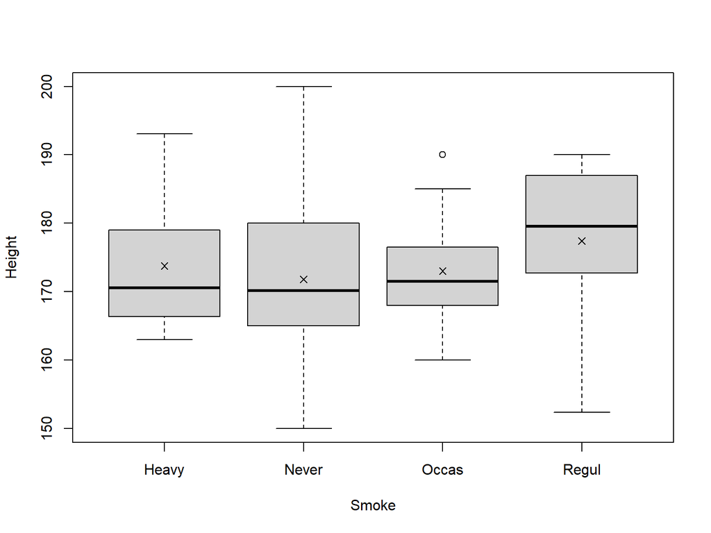

- Predictia coeficientilor

```r
survfit3 <- lm(Height~Smoke,data=survey)
summary(survfit3)
```

```
##
## Call:
## lm(formula = Height ~ Smoke, data = survey)
##
## Residuals:
##    Min     1Q Median     3Q    Max
## -25.02  -6.82  -1.64   8.18  28.18
##
## Coefficients:
##             Estimate Std. Error t value Pr(>|t|)
## (Intercept) 173.7720     3.1028  56.005   <2e-16 ***
## SmokeNever   -1.9520     3.1933  -0.611    0.542
## SmokeOccas   -0.7433     3.9553  -0.188    0.851
## SmokeRegul    3.6451     4.0625   0.897    0.371
## ---
## Signif. codes:  0 '***' 0.001 '**' 0.01 '*' 0.05 '.' 0.1 ' ' 1
##
## Residual standard error: 9.812 on 205 degrees of freedom
##   (28 observations deleted due to missingness)
## Multiple R-squared:  0.02153,    Adjusted R-squared:  0.007214
## F-statistic: 1.504 on 3 and 205 DF,  p-value: 0.2147
```

- Predictia valorilor pentru cele 4 categorii:

```
## [1] Heavy Never Occas Regul
## Levels: Heavy Never Occas Regul
```

```
##        fit      lwr      upr
## 1 173.7720 167.6545 179.8895
## 2 171.8200 170.3319 173.3081
## 3 173.0287 168.1924 177.8651
## 4 177.4171 172.2469 182.5874
```

# II. Regresia liniara multipla

Regresia liniara multipla este o generalizare directa a modelelor cu un singur predictor discutate pana acum. Aceasta permite modelarea variabilei de raspuns in functie de mai multi predictori, astfel incat sa se poate observa efectul variabilelor explicative asupra variabilei de raspuns.

# 1. Terminologie

- **Variabila lurking**: influenteaza raspunsul, alt predictor sau ambele, dar nu este inclusa intr-un model de predictie.
- **Confounding**: Prezenta unei variabile lurking poate duce la concluzii false despre relatiile de cauzalitate dintre raspuns si alt predictor sau poate masca o asociere cauza-efect adevarata. Aceasta eroare se numeste confounding.

# 2. Formula

$$Y = \beta_0 + \beta_1\ X_1 + \beta_2\ X_2 + ... + \beta_p\ X_p + \epsilon$$

$$\epsilon \sim N(0,\sigma^2)$$
unde
$$\beta_0, \beta_1, \beta_2, ... \beta_p\$$

sunt coeficientii regresiei

# **3. Reprezentare cu matrici**

$$Y = X \beta+ \epsilon$$

$$Y=\begin{bmatrix}
y_{1} \\
y_{2} \\
\vdots \\
y_{n} \\
\end{bmatrix}$$
$$X=\begin{bmatrix}
1 & x_{1,1} & \dots & x_{p,1} \\
1 & x_{1,2} & \dots & x_{p,2} \\
\vdots & \vdots & \ddots & \vdots \\
1 & x_{1,n} & \dots & x_{p,n}
\end{bmatrix}$$

$$\epsilon=\begin{bmatrix}
\epsilon_{1} \\
\epsilon_{2} \\
\vdots \\
\epsilon_{n} \\
\end{bmatrix}$$

$$\beta=\begin{bmatrix}
\beta_{1} \\
\beta_{2} \\
\vdots \\
\beta_{n} \\
\end{bmatrix}$$

# **Implementare si interpretare**

```r
survmult <- lm(Height~Wr.Hnd+Sex,data=survey)
summary(survmult)
```

```
##
## Call:
## lm(formula = Height ~ Wr.Hnd + Sex, data = survey)
##
## Residuals:
##      Min       1Q   Median       3Q      Max
## -17.7479  -4.1830   0.7749   4.6665  21.9253
##
## Coefficients:
##             Estimate Std. Error t value Pr(>|t|)
## (Intercept) 137.6870     5.7131  24.100  < 2e-16 ***
## Wr.Hnd        1.5944     0.3229   4.937 1.64e-06 ***
## SexMale       9.4898     1.2287   7.724 5.00e-13 ***
## ---
## Signif. codes:  0 '***' 0.001 '**' 0.01 '*' 0.05 '.' 0.1 ' ' 1
##
## Residual standard error: 6.987 on 204 degrees of freedom
##   (30 observations deleted due to missingness)
## Multiple R-squared:  0.5062, Adjusted R-squared:  0.5014
## F-statistic: 104.6 on 2 and 204 DF,  p-value: < 2.2e-16
```

# **5. Interpretarea efectelor marginale**

In regresia multipla, estimarea fiecarui predictor ia in considerare efectul tuturor celorlaltor predictori prezenti in model. In cazul nostru, pentru studentii de acelasi sex, cresterea de 1 cm in intinderea palmei conduce la o crestere estimata de 1.5944 cm in inaltimea medie.

Pentru studentii cu intinderea palmei similara, barbatii in medie vor fi cu 9.4898 cm mai inalti decat femeile.

Se observa astfel utilitatea regresiei multiple. In acest exemplu, daca folosim doar regresia liniara simpla, rezultatul este inselator, deoarece o parte din variatia inaltimii este determinata de sex, in timp ce alta este atribuita intinderii palmei.

# **Interpretarea efectelor marginale**

Modelul poate fi exprimat in urmatorul mod:

*Mean height* = 137.687 + 1.594 × *handspan* + 9.49 × *sex*

# **6. Vizualizarea modelului**

```r
survcoefs <- coef(survmult)
survcoefs
```

```
## (Intercept)      Wr.Hnd     SexMale
##  137.686951    1.594446    9.489814
```

```r
as.numeric(survcoefs[1]+survcoefs[3])
```

```
## [1] 147.1768
```

Poate fi scris ca 2 ecuatii, una pentru femei si una pentru barbati:

- *Ecuatia pentru femei:*

*Mean height* = 137.687 + 1.594 × *handspan*

- *Ecuatia pentru barbati:*

*Mean height* = (137.687 + 9.4898) + 1.594 × *handspan* = 147.177 + 1.594 × *handspan*

# **Vizualizarea modelului**

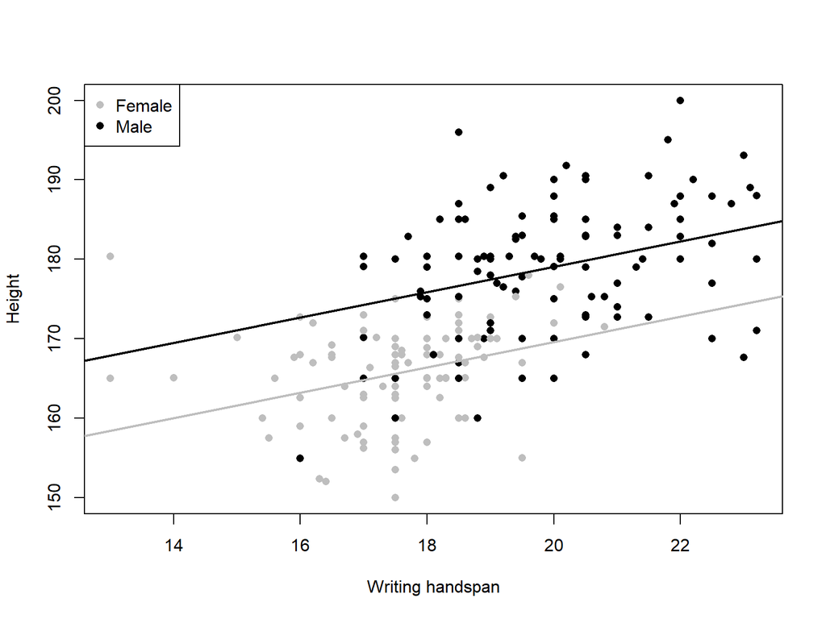

```r
survcoefs <- coef(survmult)
plot(survey$Height~survey$Wr.Hnd,
        col=c("gray","black")[as.numeric(survey$Sex)],
        pch=16,xlab="Writing handspan",ylab="Height")
abline(a=survcoefs[1],b=survcoefs[2],col="gray",lwd=2)
abline(a=survcoefs[1]+survcoefs[3],b=survcoefs[2],col="black",lwd=2)
legend("topleft",legend=levels(survey$Sex),col=c("gray","black"),pch=16)
```

# **7. Predictie pornind de la un model de regresie liniara multipla**

Ca exemplu, folosind modelul pentru inaltimea unui student ca functie liniara de handspan si sex, putem estima inaltimea medie a unui student de sex masculin cu o intindere a palmei de 16.5 cm, impreuna cu un interval de incredere.

```r
predict(survmult,newdata=data.frame(Wr.Hnd=16.5,Sex="Male"),
           interval="confidence",level=0.95)
```

```
##        fit      lwr      upr
## 1 173.4851 170.9419 176.0283
```

```r
predict(survmult,newdata=data.frame(Wr.Hnd=13,Sex="Female"),
           interval="prediction",level=0.99)
```

```
##        fit      lwr      upr
## 1 158.4147 139.7611 177.0684
```

# **8. Transformarea variabilelor numerice**

**Transformarea numerica** se refera la aplicarea unei functii matematice asupra valorilor numerice pentru a le redimensiona. Exemplu: radacina patrata a unui numar sau transformarea din Fahrenheit in Celsius.

- *transformare polinomiala*
- *transformare logaritmica*

# **Transformare polinomiala**

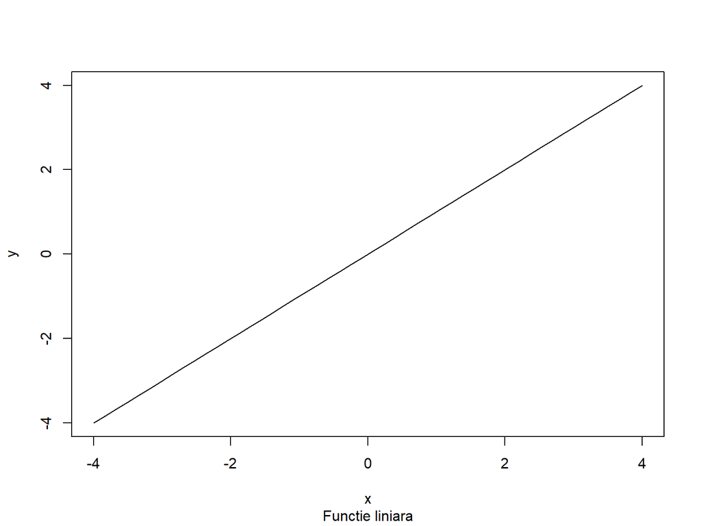

```r
x <- seq(-4,4,length=50)
y<-x
y2<-x+x^2
y3<-x+x^2+x^3

plot(x,y,type="l", sub="Functie liniara")
```

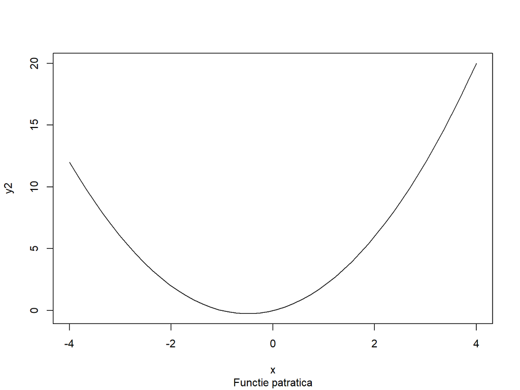

```r
plot(x,y2,type="l", sub="Functie patratica")
```

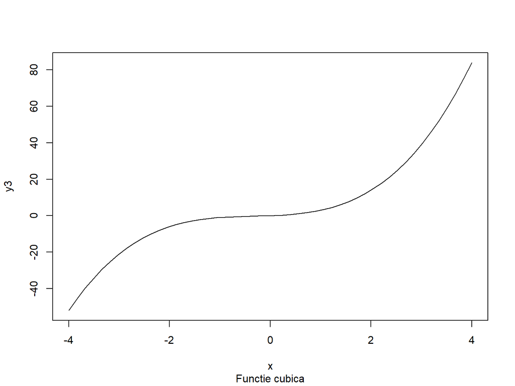

```r
plot(x,y3,type="l", sub="Functie cubica")
```

# **Transformare polinomiala**

Folosim setul de date *mtcars*, pentru care consideram variabila *disp*, care descrie volumul deplasarii motorului in inch cubi si variabila de raspuns *mile per galon*.

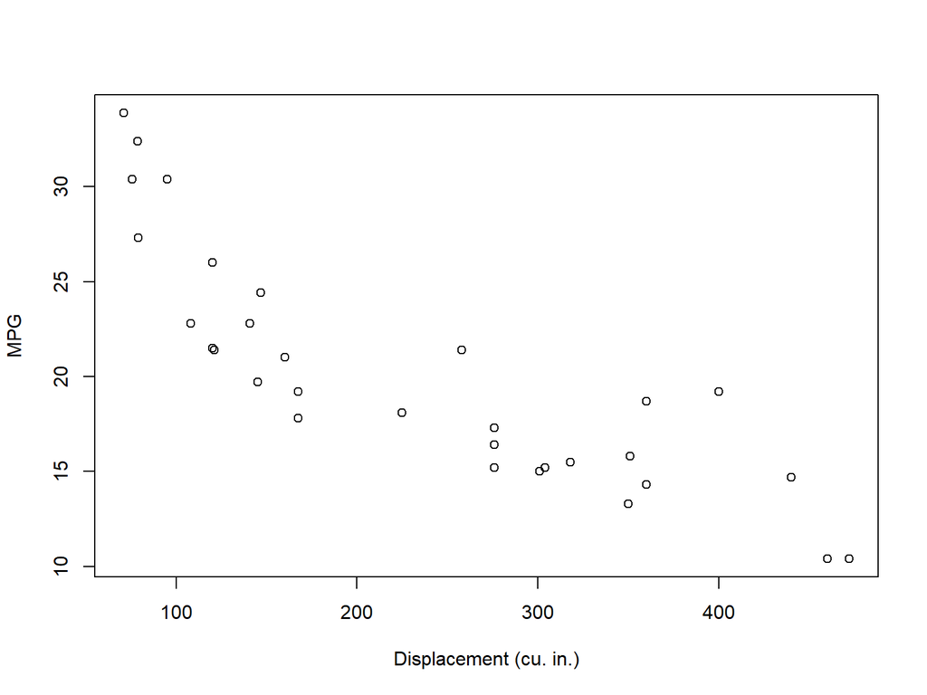

```r
plot(mtcars$disp,mtcars$mpg,xlab="Displacement (cu. in.)",ylab="MPG")
```

# a) Regresie liniara simpla

```r
car.order1 <- lm(mpg~disp,data=mtcars)
summary(car.order1)
```

```
##
## Call:
## lm(formula = mpg ~ disp, data = mtcars)
##
## Residuals:
##     Min      1Q  Median      3Q     Max
## -4.8922 -2.2022 -0.9631  1.6272  7.2305
##
## Coefficients:
##              Estimate Std. Error t value Pr(>|t|)
## (Intercept) 29.599855   1.229720  24.070  < 2e-16 ***
## disp        -0.041215   0.004712  -8.747 9.38e-10 ***
## ---
## Signif. codes:  0 '***' 0.001 '**' 0.01 '*' 0.05 '.' 0.1 ' ' 1
##
## Residual standard error: 3.251 on 30 degrees of freedom
## Multiple R-squared:  0.7183, Adjusted R-squared:  0.709
## F-statistic: 76.51 on 1 and 30 DF,  p-value: 9.38e-10
```

# b) Regresie liniara multipla

```r
car.order2 <- lm(mpg~disp+I(disp^2),data=mtcars)
summary(car.order2)
```

```
##
## Call:
## lm(formula = mpg ~ disp + I(disp^2), data = mtcars)
##
## Residuals:
##     Min      1Q  Median      3Q     Max
## -3.9112 -1.5269 -0.3124  1.3489  5.3946
##
## Coefficients:
##               Estimate Std. Error t value Pr(>|t|)
## (Intercept)  3.583e+01  2.209e+00  16.221 4.39e-16 ***
## disp        -1.053e-01  2.028e-02  -5.192 1.49e-05 ***
## I(disp^2)    1.255e-04  3.891e-05   3.226   0.0031 **
## ---
## Signif. codes:  0 '***' 0.001 '**' 0.01 '*' 0.05 '.' 0.1 ' ' 1
##
## Residual standard error: 2.837 on 29 degrees of freedom
## Multiple R-squared:  0.7927, Adjusted R-squared:  0.7784
## F-statistic: 55.46 on 2 and 29 DF,  p-value: 1.229e-10
```

# c) Regresie liniara multipla

```r
car.order3 <- lm(mpg~disp+I(disp^2)+I(disp^3),data=mtcars)
summary(car.order3)
```

```
##
## Call:
## lm(formula = mpg ~ disp + I(disp^2) + I(disp^3), data = mtcars)
##
## Residuals:
##     Min      1Q  Median      3Q     Max
## -3.0896 -1.5653 -0.3619  1.4368  4.7617
##
## Coefficients:
##               Estimate Std. Error t value Pr(>|t|)
## (Intercept)  5.070e+01  3.809e+00  13.310 1.25e-13 ***
## disp        -3.372e-01  5.526e-02  -6.102 1.39e-06 ***
## I(disp^2)    1.109e-03  2.265e-04   4.897 3.68e-05 ***
## I(disp^3)   -1.217e-06  2.776e-07  -4.382  0.00015 ***
## ---
## Signif. codes:  0 '***' 0.001 '**' 0.01 '*' 0.05 '.' 0.1 ' ' 1
##
## Residual standard error: 2.224 on 28 degrees of freedom
## Multiple R-squared:  0.8771, Adjusted R-squared:  0.8639
## F-statistic: 66.58 on 3 and 28 DF,  p-value: 7.347e-13
```

# d) Plot

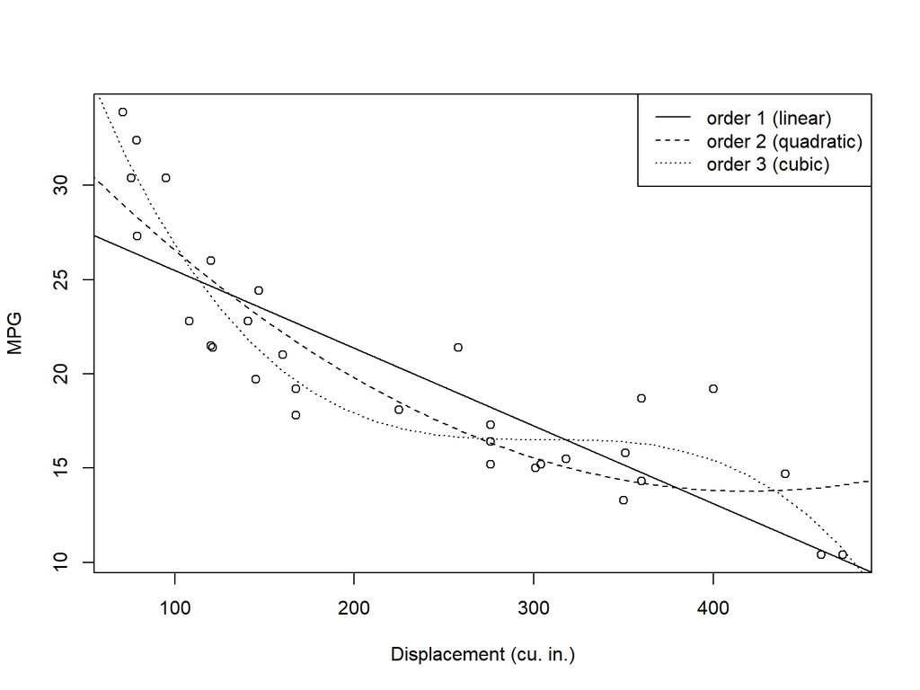

```r
plot(mtcars$disp,mtcars$mpg,xlab="Displacement (cu. in.)",ylab="MPG")
abline(car.order1)
disp.seq <- seq(min(mtcars$disp)-50,max(mtcars$disp)+50,length=30)

car.order2.pred <- predict(car.order2,newdata=data.frame(disp=disp.seq))
lines(disp.seq,car.order2.pred,lty=2)


car.order3.pred <- predict(car.order3,newdata=data.frame(disp=disp.seq))
lines(disp.seq,car.order3.pred,lty=3)
legend("topright",lty=1:3,
          legend=c("order 1 (linear)","order 2 (quadratic)","order 3 (cubic)"))
```

# III.Selectarea și cercetarea modelelor de regresii liniare

### **1. Complexitate vs. Acuratete**

Concepte esentiale in validarea modelelor de regresie liniara:

- selectarea unui model potrivit analizei
- validarea ipotezelor de lucru

### **2. Principiul Parcimoniei**

Urmareste obtinerea unui model de complexitate cat mai scazuta, dar fara a sacrifica prea mult din precizia modelului.

# **3. Algoritmi de selectie a modelelor**

### **3.1. Nested Comparasions: The Partial F-Test**

Testul Partial F este o metoda de comparare dintre 2 modele, unde modelul mai putin complex este o versiune redusa a celuilalt.

$$\hat{y}_{redu} = \hat{\beta_0} + \hat{\beta_{1}}\ x_1 + \hat{\beta_{2}}\ x_2 + ... + \hat{\beta_{p}}\ x_p$$
$$\hat{y}_{full} = \hat{\beta_0} + \hat{\beta_{1}}\ x_1 + \hat{\beta_{2}}\ x_2 + ... + \hat{\beta_{p}}\ x_p + ... + \hat{\beta_{q}}\ x_q$$
Scopul acestui test este de a verifica daca se va imbunatati dpdv statistic modelul prin obtinerea unui model mai complex prin adaugarea celor q-p variabile.

```r
library(MASS)
data(survey)
survmult <- lm(Height ~ Wr.Hnd + Sex, data = survey)
survmult2 <- lm(Height ~ Wr.Hnd + Sex + Smoke, data = survey)
anova(survmult, survmult2)
```

```
## Analysis of Variance Table
##
## Model 1: Height ~ Wr.Hnd + Sex
## Model 2: Height ~ Wr.Hnd + Sex + Smoke
##   Res.Df    RSS Df Sum of Sq      F Pr(>F)
## 1    204 9959.2
## 2    201 9914.3  3    44.876 0.3033  0.823
```

# **3.2. Forward Selection**

Forward Selection porneste de la un model trivial, dupa care se executa o serie de teste pentru a vedea care variabila imbunatateste cel mai mult modelul. Acesta se actualizeaza si se repeta procesul pana cand nu mai exista termeni care sa perfectioneze semnificativ modelul.

```r
library(boot)

nuc.0 <- lm(cost ~ 1, data = nuclear)
summary(nuc.0)
```

```
##
## Call:
## lm(formula = cost ~ 1, data = nuclear)
##
## Residuals:
##     Min      1Q  Median      3Q     Max
## -254.05 -151.24  -13.46  150.40  419.68
##
## Coefficients:
##             Estimate Std. Error t value Pr(>|t|)
## (Intercept)   461.56      30.07   15.35 4.95e-16 ***
## ---
## Signif. codes:  0 '***' 0.001 '**' 0.01 '*' 0.05 '.' 0.1 ' ' 1
##
## Residual standard error: 170.1 on 31 degrees of freedom
```

```r
add1(nuc.0, scope = .~. + date + t1 + t2 + cap + pr +ne + ct + bw + cum.n + pt, test = "F")
```

```
## Single term additions
##
## Model:
## cost ~ 1
##        Df Sum of Sq    RSS    AIC F value    Pr(>F)
## <none>              897172 329.72
## date    1    334335 562837 316.80 17.8205 0.0002071 ***
## t1      1    186984 710189 324.24  7.8986 0.0086296 **
## t2      1        27 897145 331.72  0.0009 0.9760597
## cap     1    199673 697499 323.66  8.5881 0.0064137 **
## pr      1      9037 888136 331.40  0.3052 0.5847053
## ne      1    128641 768531 326.77  5.0216 0.0325885 *
## ct      1     43042 854130 330.15  1.5118 0.2284221
## bw      1     16205 880967 331.14  0.5519 0.4633402
## cum.n   1     67938 829234 329.20  2.4579 0.1274266
## pt      1    305334 591839 318.41 15.4772 0.0004575 ***
## ---
## Signif. codes:  0 '***' 0.001 '**' 0.01 '*' 0.05 '.' 0.1 ' ' 1
```

```r
nuc.1 <- update(nuc.0, formula = .~. + date)
summary(nuc.1)
```

```
##
## Call:
## lm(formula = cost ~ date, data = nuclear)
##
## Residuals:
##     Min      1Q  Median      3Q     Max
## -176.00 -105.27  -25.24   58.63  359.46
##
## Coefficients:
##             Estimate Std. Error t value Pr(>|t|)
## (Intercept) -6553.57    1661.96  -3.943 0.000446 ***
## date          102.29      24.23   4.221 0.000207 ***
## ---
## Signif. codes:  0 '***' 0.001 '**' 0.01 '*' 0.05 '.' 0.1 ' ' 1
##
## Residual standard error: 137 on 30 degrees of freedom
## Multiple R-squared:  0.3727, Adjusted R-squared:  0.3517
## F-statistic: 17.82 on 1 and 30 DF,  p-value: 0.0002071
```

```r
add1(nuc.1, scope = .~. + date + t1 + t2 +cap + pr + ne + ct + bw + cum.n + pt, test="F")
```

```
## Single term additions
##
## Model:
## cost ~ date
##        Df Sum of Sq    RSS    AIC F value    Pr(>F)
## <none>              562837 316.80
## t1      1     15322 547515 317.92  0.8115 0.3750843
## t2      1     68161 494676 314.67  3.9959 0.0550606 .
## cap     1    189732 373105 305.64 14.7471 0.0006163 ***
## pr      1      4027 558810 318.57  0.2090 0.6509638
## ne      1     92256 470581 313.07  5.6854 0.0238671 *
## ct      1     54794 508043 315.52  3.1277 0.0874906 .
## bw      1      1240 561597 318.73  0.0640 0.8020147
## cum.n   1      4658 558179 318.53  0.2420 0.6264574
## pt      1     90587 472250 313.18  5.5628 0.0252997 *
## ---
## Signif. codes:  0 '***' 0.001 '**' 0.01 '*' 0.05 '.' 0.1 ' ' 1
```

```r
nuc.2 <- update(nuc.1, formula = .~. + cap)
summary(nuc.2)
```

```
##
## Call:
## lm(formula = cost ~ date + cap, data = nuclear)
##
## Residuals:
##      Min       1Q   Median       3Q      Max
## -146.351  -88.244   -2.202   58.457  267.741
##
## Coefficients:
##               Estimate Std. Error t value Pr(>|t|)
## (Intercept) -6790.8792  1377.6683  -4.929 3.09e-05 ***
## date          100.7764    20.0696   5.021 2.39e-05 ***
## cap             0.4132     0.1076   3.840 0.000616 ***
## ---
## Signif. codes:  0 '***' 0.001 '**' 0.01 '*' 0.05 '.' 0.1 ' ' 1
##
## Residual standard error: 113.4 on 29 degrees of freedom
## Multiple R-squared:  0.5841, Adjusted R-squared:  0.5555
## F-statistic: 20.37 on 2 and 29 DF,  p-value: 2.984e-06
```

```r
add1(nuc.2, scope = .~. + date + t1 + t2 + cap + pr + ne + ct + bw + cum.n + pt, test="F")
```

```
## Single term additions
##
## Model:
## cost ~ date + cap
##        Df Sum of Sq    RSS    AIC F value   Pr(>F)
## <none>              373105 305.64
## t1      1       957 372148 307.56  0.0720 0.790387
## t2      1     13356 359750 306.48  1.0395 0.316670
## pr      1     18453 354652 306.02  1.4569 0.237521
## ne      1     94537 278569 298.29  9.5022 0.004575 **
## ct      1     48957 324148 303.14  4.2289 0.049169 *
## bw      1      7505 365601 306.99  0.5748 0.454705
## cum.n   1     28062 345044 305.14  2.2772 0.142493
## pt      1     95917 277189 298.13  9.6889 0.004243 **
## ---
## Signif. codes:  0 '***' 0.001 '**' 0.01 '*' 0.05 '.' 0.1 ' ' 1
```

```r
nuc.3 <- update(nuc.2, formula = .~. + pt)
summary(nuc.3)
```

```
##
## Call:
## lm(formula = cost ~ date + cap + pt, data = nuclear)
##
## Residuals:
##     Min      1Q  Median      3Q     Max
## -190.11  -56.21  -13.90   35.57  237.92
##
## Coefficients:
##               Estimate Std. Error t value Pr(>|t|)
## (Intercept) -4.553e+03  1.406e+03  -3.238 0.003091 **
## date         6.852e+01  2.043e+01   3.355 0.002296 **
## cap          4.191e-01  9.441e-02   4.439 0.000128 ***
## pt          -1.628e+02  5.229e+01  -3.113 0.004243 **
## ---
## Signif. codes:  0 '***' 0.001 '**' 0.01 '*' 0.05 '.' 0.1 ' ' 1
##
## Residual standard error: 99.5 on 28 degrees of freedom
## Multiple R-squared:  0.691,  Adjusted R-squared:  0.6579
## F-statistic: 20.88 on 3 and 28 DF,  p-value: 2.64e-07
```

```r
add1(nuc.3, scope = .~. + date + t1 + t2 + cap + pr + ne + ct + bw + cum.n + pt, test="F")
```

```
## Single term additions
##
## Model:
## cost ~ date + cap + pt
##        Df Sum of Sq    RSS    AIC F value  Pr(>F)
## <none>              277189 298.13
## t1      1        12 277177 300.13  0.0011 0.97352
## t2      1     10429 266760 298.91  1.0555 0.31335
## pr      1      6017 271171 299.43  0.5991 0.44564
## ne      1     54572 222617 293.12  6.6187 0.01591 *
## ct      1     18119 259069 297.97  1.8884 0.18068
## bw      1       654 276535 300.06  0.0639 0.80241
## cum.n   1       463 276726 300.08  0.0451 0.83334
## ---
## Signif. codes:  0 '***' 0.001 '**' 0.01 '*' 0.05 '.' 0.1 ' ' 1
```

```r
nuc.4 <- update(nuc.3, formula = .~. + ne)
summary(nuc.4)
```

```
##
## Call:
## lm(formula = cost ~ date + cap + pt + ne, data = nuclear)
##
## Residuals:
##      Min       1Q   Median       3Q      Max
## -157.894  -38.424   -2.493   35.363  267.445
##
## Coefficients:
##               Estimate Std. Error t value Pr(>|t|)
## (Intercept) -4.756e+03  1.286e+03  -3.699 0.000975 ***
## date         7.102e+01  1.867e+01   3.804 0.000741 ***
## cap          4.198e-01  8.616e-02   4.873 4.29e-05 ***
## pt          -1.289e+02  4.950e+01  -2.605 0.014761 *
## ne           9.940e+01  3.864e+01   2.573 0.015908 *
## ---
## Signif. codes:  0 '***' 0.001 '**' 0.01 '*' 0.05 '.' 0.1 ' ' 1
##
## Residual standard error: 90.8 on 27 degrees of freedom
## Multiple R-squared:  0.7519, Adjusted R-squared:  0.7151
## F-statistic: 20.45 on 4 and 27 DF,  p-value: 7.507e-08
```

```r
add1(nuc.4, scope = .~. + date + t1 + t2 + cap + pr + ne + ct + bw + cum.n + pt, test="F")
```

```
## Single term additions
##
## Model:
## cost ~ date + cap + pt + ne
##        Df Sum of Sq    RSS    AIC F value Pr(>F)
## <none>              222617 293.12
## t1      1     107.0 222510 295.10  0.0125 0.9118
## t2      1   19229.9 203387 292.23  2.4583 0.1290
## pr      1    5230.8 217386 294.36  0.6256 0.4361
## ct      1   15764.7 206852 292.77  1.9815 0.1711
## bw      1     448.0 222169 295.06  0.0524 0.8207
## cum.n   1   13819.9 208797 293.07  1.7209 0.2010
```

# **3.3. Backward Selection**

Backward Selection are un comportament asemanator cu Forward Selection, cu exceptia faptului ca acesta porneste de la cel mai complex model si elimina succesiv cate o variabila.

```r
nuc.0 <- lm(cost ~ date + t1 + t2 + cap + pr + ne + ct + bw + cum.n + pt, data = nuclear)

drop1(nuc.0, test = "F")
```

```
## Single term deletions
##
## Model:
## cost ~ date + t1 + t2 + cap + pr + ne + ct + bw + cum.n + pt
##        Df Sum of Sq    RSS    AIC F value    Pr(>F)
## <none>              144065 291.19
## date    1     51230 195295 298.93  7.4677 0.0124702 *
## t1      1      2034 146099 289.64  0.2965 0.5918028
## t2      1     28481 172546 294.97  4.1517 0.0543902 .
## cap     1    155943 300008 312.67 22.7314 0.0001039 ***
## pr      1     27161 171226 294.72  3.9592 0.0597943 .
## ne      1     86581 230646 304.25 12.6207 0.0018835 **
## ct      1     10915 154980 291.53  1.5911 0.2210075
## bw      1       173 144238 289.23  0.0252 0.8753538
## cum.n   1     22939 167004 293.92  3.3438 0.0816977 .
## pt      1       627 144692 289.33  0.0914 0.7654015
## ---
## Signif. codes:  0 '***' 0.001 '**' 0.01 '*' 0.05 '.' 0.1 ' ' 1
```

```r
nuc.1 <- update(nuc.0, .~. - bw)

drop1(nuc.1, test = "F")
```

```
## Single term deletions
##
## Model:
## cost ~ date + t1 + t2 + cap + pr + ne + ct + cum.n + pt
##        Df Sum of Sq    RSS    AIC F value    Pr(>F)
## <none>              144238 289.23
## date    1     55942 200180 297.72  8.5326  0.007913 **
## t1      1      3124 147362 287.92  0.4765  0.497245
## t2      1     30717 174955 293.41  4.6852  0.041546 *
## cap     1    159976 304214 311.11 24.4005 6.098e-05 ***
## pr      1     27140 171377 292.75  4.1395  0.054122 .
## ne      1     86408 230646 302.25 13.1795  0.001479 **
## ct      1     11815 156053 289.75  1.8021  0.193153
## cum.n   1     24048 168286 292.17  3.6680  0.068557 .
## pt      1       930 145168 287.44  0.1419  0.710039
## ---
## Signif. codes:  0 '***' 0.001 '**' 0.01 '*' 0.05 '.' 0.1 ' ' 1
```

```r
nuc.2 <- update(nuc.1, .~. - pt)

drop1(nuc.2, test = "F")
```

```
## Single term deletions
##
## Model:
## cost ~ date + t1 + t2 + cap + pr + ne + ct + cum.n
##        Df Sum of Sq    RSS    AIC F value    Pr(>F)
## <none>              145168 287.44
## date    1     93677 238845 301.37 14.8419 0.0008108 ***
## t1      1      2853 148021 286.06  0.4521 0.5080427
## t2      1     31312 176480 291.69  4.9610 0.0359961 *
## cap     1    165594 310762 309.79 26.2363 3.447e-05 ***
## pr      1     29984 175152 291.45  4.7506 0.0397817 *
## ne      1    113659 258827 303.94 18.0077 0.0003069 ***
## ct      1     15602 160770 288.70  2.4719 0.1295556
## cum.n   1     48482 193650 294.66  7.6814 0.0108561 *
## ---
## Signif. codes:  0 '***' 0.001 '**' 0.01 '*' 0.05 '.' 0.1 ' ' 1
```

```r
nuc.3 <- update(nuc.2, .~. - t1)

drop1(nuc.3, test = "F")
```

```
## Single term deletions
##
## Model:
## cost ~ date + t2 + cap + pr + ne + ct + cum.n
##        Df Sum of Sq    RSS    AIC F value    Pr(>F)
## <none>              148021 286.06
## date    1    369019 517040 324.08 59.8322 5.697e-08 ***
## t2      1     28539 176560 289.70  4.6272 0.0417479 *
## cap     1    162846 310867 307.80 26.4036 2.928e-05 ***
## pr      1     27209 175230 289.46  4.4116 0.0463857 *
## ne      1    114114 262135 302.35 18.5023 0.0002454 ***
## ct      1     15200 163222 287.19  2.4645 0.1295338
## cum.n   1     53288 201310 293.90  8.6401 0.0071635 **
## ---
## Signif. codes:  0 '***' 0.001 '**' 0.01 '*' 0.05 '.' 0.1 ' ' 1
```

```r
nuc.4 <- update(nuc.3, .~. - ct)

drop1(nuc.4, test="F")
```

```
## Single term deletions
##
## Model:
## cost ~ date + t2 + cap + pr + ne + cum.n
##        Df Sum of Sq    RSS    AIC F value    Pr(>F)
## <none>              163222 287.19
## date    1    374577 537799 323.34 57.3725 6.272e-08 ***
## t2      1     47075 210297 293.30  7.2103  0.012685 *
## cap     1    157450 320672 306.80 24.1160 4.695e-05 ***
## pr      1     42270 205492 292.56  6.4743  0.017499 *
## ne      1    127488 290709 303.66 19.5268  0.000168 ***
## cum.n   1     49676 212898 293.69  7.6087  0.010703 *
## ---
## Signif. codes:  0 '***' 0.001 '**' 0.01 '*' 0.05 '.' 0.1 ' ' 1
```

# **3.4. Stepwise AIC Selection**

Acest algoritm le combina pe cele precedente, astfel ca la fiecare pas, o variabila poate fi adaugata sau eliminata din modelul curent.

$$AIC = -2L + 2(p + 2)$$

```r
car.null <- lm(mpg ~ 1, data = mtcars)
car.step <- step(car.null, scope = .~. + wt * hp * factor(cyl) * disp + am
                 + factor(gear) + drat + vs + qsec + carb)
```

```
## Start:  AIC=115.94
## mpg ~ 1
##
##                Df Sum of Sq     RSS     AIC
## + wt            1    847.73  278.32  73.217
## + disp          1    808.89  317.16  77.397
## + factor(cyl)   2    824.78  301.26  77.752
## + hp            1    678.37  447.67  88.427
## + drat          1    522.48  603.57  97.988
## + vs            1    496.53  629.52  99.335
## + factor(gear)  2    483.24  642.80 102.003
## + am            1    405.15  720.90 103.672
## + carb          1    341.78  784.27 106.369
## + qsec          1    197.39  928.66 111.776
## <none>                      1126.05 115.943
##
## Step:  AIC=73.22
## mpg ~ wt
##
##                Df Sum of Sq     RSS     AIC
## + factor(cyl)   2     95.26  183.06  63.810
## + hp            1     83.27  195.05  63.840
## + qsec          1     82.86  195.46  63.908
## + vs            1     54.23  224.09  68.283
## + carb          1     44.60  233.72  69.628
## + disp          1     31.64  246.68  71.356
## + factor(gear)  2     40.37  237.95  72.202
## <none>                       278.32  73.217
## + drat          1      9.08  269.24  74.156
## + am            1      0.00  278.32  75.217
## - wt            1    847.73 1126.05 115.943
##
## Step:  AIC=63.81
## mpg ~ wt + factor(cyl)
##
##                  Df Sum of Sq    RSS    AIC
## + hp              1    22.281 160.78 61.657
## + wt:factor(cyl)  2    27.170 155.89 62.669
## <none>                        183.06 63.810
## + qsec            1    10.949 172.11 63.837
```

[output cut: 59 more lines]

```
##
## Step:  AIC=52.57
## mpg ~ wt + hp + qsec + wt:hp
##
##                Df Sum of Sq    RSS    AIC
## <none>                      121.04 52.573
## - qsec          1     8.720 129.76 52.799
## + factor(gear)  2     9.482 111.56 53.962
## + am            1     1.939 119.10 54.056
## + carb          1     0.080 120.96 54.551
## + drat          1     0.012 121.03 54.570
## + vs            1     0.010 121.03 54.570
## + disp          1     0.008 121.03 54.571
## + factor(cyl)   2     0.164 120.88 56.529
## - wt:hp         1    65.018 186.06 64.331
```

```r
summary(car.step)
```

```
##
## Call:
## lm(formula = mpg ~ wt + hp + qsec + wt:hp, data = mtcars)
##
## Residuals:
##     Min      1Q  Median      3Q     Max
## -3.8243 -1.3980  0.0303  1.1582  4.3650
##
## Coefficients:
##              Estimate Std. Error t value Pr(>|t|)
## (Intercept) 40.310410   7.677887   5.250 1.56e-05 ***
## wt          -8.681516   1.292525  -6.717 3.28e-07 ***
## hp          -0.106181   0.026263  -4.043 0.000395 ***
## qsec         0.503163   0.360768   1.395 0.174476
## wt:hp        0.027791   0.007298   3.808 0.000733 ***
## ---
## Signif. codes:  0 '***' 0.001 '**' 0.01 '*' 0.05 '.' 0.1 ' ' 1
##
## Residual standard error: 2.117 on 27 degrees of freedom
## Multiple R-squared:  0.8925, Adjusted R-squared:  0.8766
## F-statistic: 56.05 on 4 and 27 DF,  p-value: 1.094e-12
```

# **4.Interpretarea datelor**

Este important sa se investigheze orice observatie care pare neobisnuita sau extrema in comparatie cu restul setului de date. Se definesc termenii:

1. **Valoare aberanta** (outlier) - observatie care arata neobisnuit in contextul unui set de date
2. **Punct parghie** (leverage) - o observatie a carei valoare x este neobisnuita, dar a carei valoare prezisa y se conformeaza cu trendul si urmeaza linia de regresie prezisa.
3. **Valoare influenta** (influence) - o observatie cu un efect de levier mare si care, in consecinta, afecteaza linia de regresie

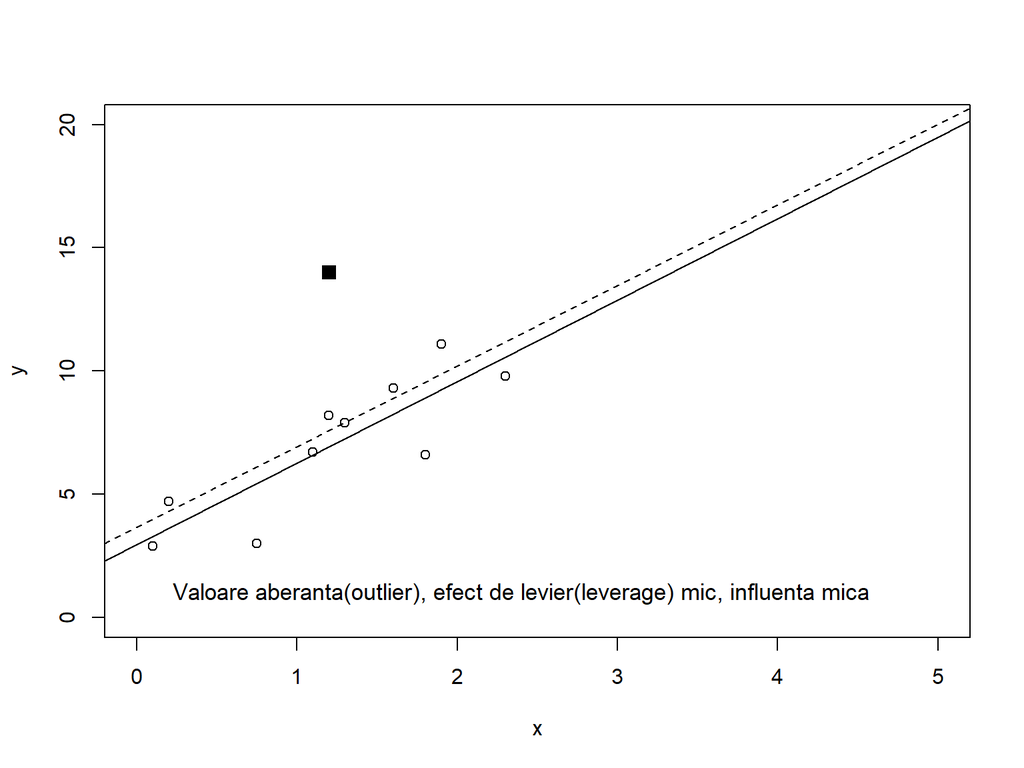

```r
x <- c(1.1, 1.3, 2.3, 1.6, 1.2, 0.1, 1.8, 1.9, 0.2, 0.75)
y <- c(6.7, 7.9, 9.8, 9.3, 8.2, 2.9, 6.6, 11.1, 4.7, 3)
p1x <- 1.2
p1y <- 14
p2x <- 5
p2y <- 19
p3x <- 5
p3y <- 5

mod.0 <- lm(y~x)
mod.1 <- lm(c(y, p1y) ~ c(x, p1x))
mod.2 <- lm(c(y, p2y) ~ c(x, p2x))
mod.3 <- lm(c(y, p3y) ~ c(x, p3x))

plot(x, y, xlim = c(0, 5), ylim = c(0, 20))
points(p1x, p1y, pch = 15, cex = 1.5)
abline(mod.0)
abline(mod.1, lty = 2)
text(2.4, 1, labels = "Valoare aberanta(outlier), efect de levier(leverage) mic, influenta mica", cex = 1.1)
```

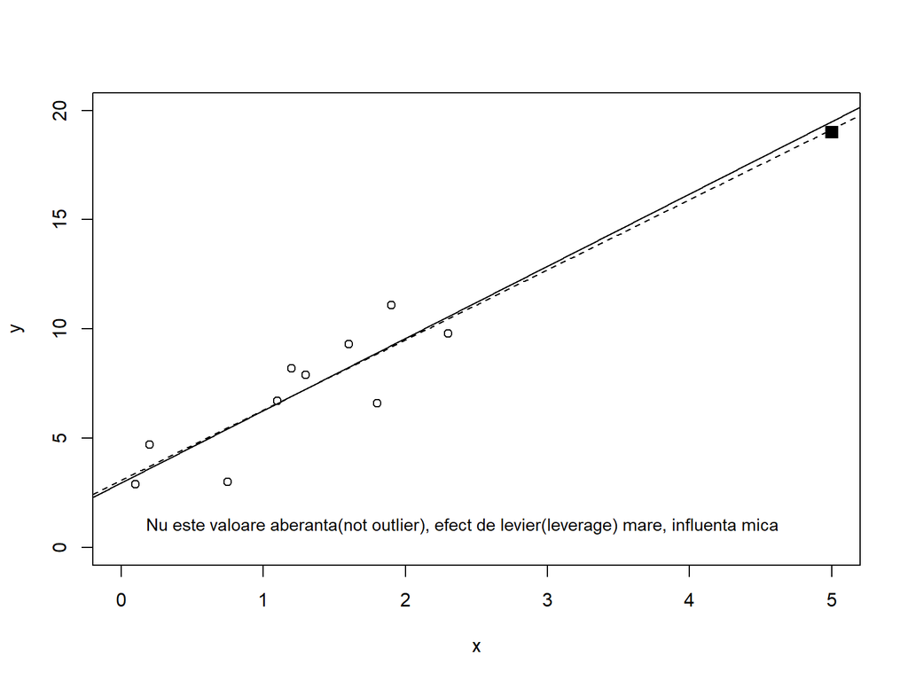

```r
plot(x, y, xlim = c(0, 5), ylim = c(0, 20))
points(p2x, p2y, pch = 15, cex = 1.5)
abline(mod.0)
abline(mod.2, lty = 2)
text(2.4, 1, labels = "Nu este valoare aberanta(not outlier), efect de levier(leverage) mare, influenta mica", cex = 0.9)
```

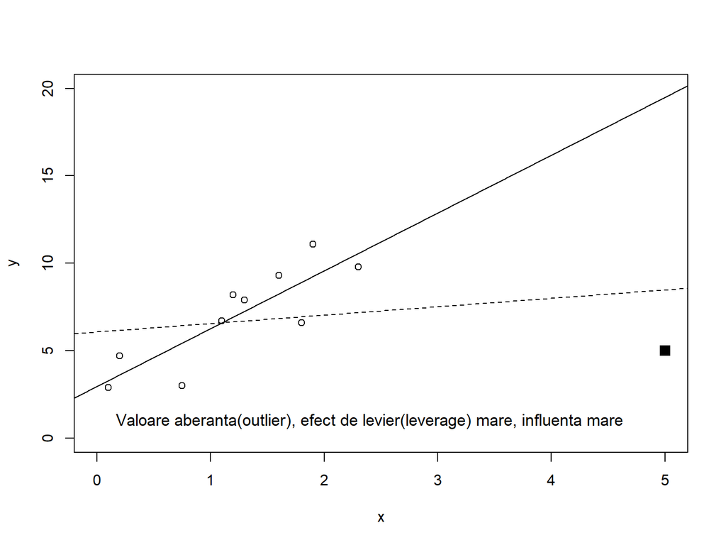

```r
plot(x, y, xlim = c(0, 5), ylim = c(0, 20))
points(p3x, p3y, pch = 15, cex = 1.5)
abline(mod.0)
abline(mod.3, lty = 2)
text(2.4, 1, labels = "Valoare aberanta(outlier), efect de levier(leverage) mare, influenta mare", cex = 1.1)
```

### **5.Distanta Cook**

O alta metrica importanta pentru determinarea gradului de influenta a unei observatii o reprezinta distanta Cook care estimeaza amploarea efectului de eliminare a observatiei i din modelul adaptat.

$$D_{i} = \sum_{j=1}^{n} \frac{(\hat{y_{j}} - \hat{y_{j}}^{(-i)})^2}{(p+1)\hat{\sigma}^{2}}, \space \space \space \space i,j=1, \dots ,n$$

# **6.Combinarea metricilor prezentate**

Pentru o mai buna intelegere a observatiilor si efectele pe care acestea le au asupra regresiilor liniare, metricile prezentate pot fi combinate intr-o singura reprezentare grafica.

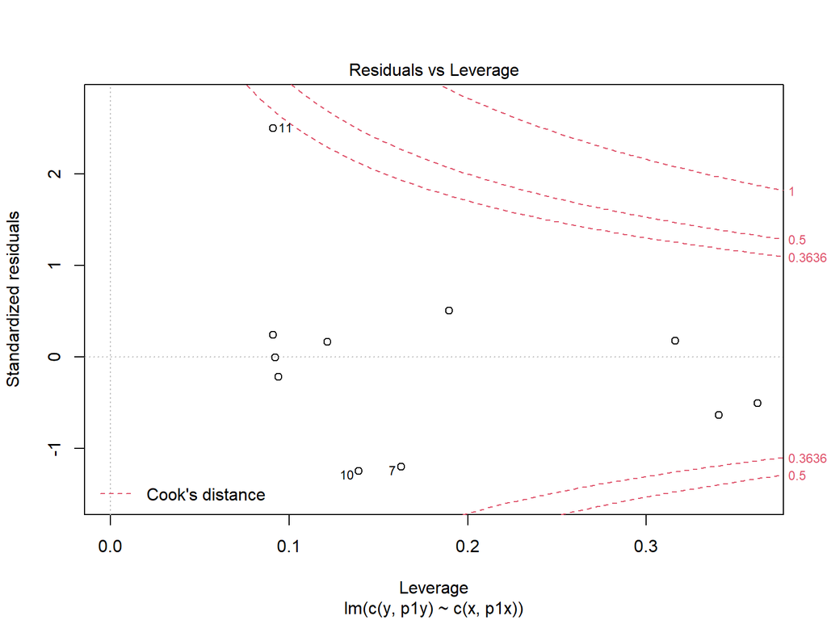

```r
plot(mod.1, which = 5, add.smooth = FALSE, cook.levels = c(4 / 11, 0.5, 1))
```

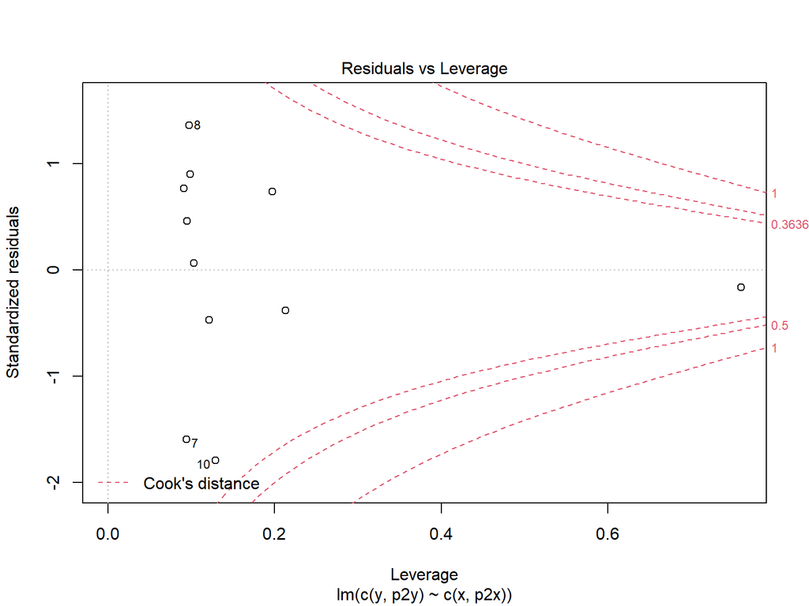

```r
plot(mod.2, which = 5, add.smooth = FALSE, cook.levels = c(4 / 11, 0.5, 1))
```

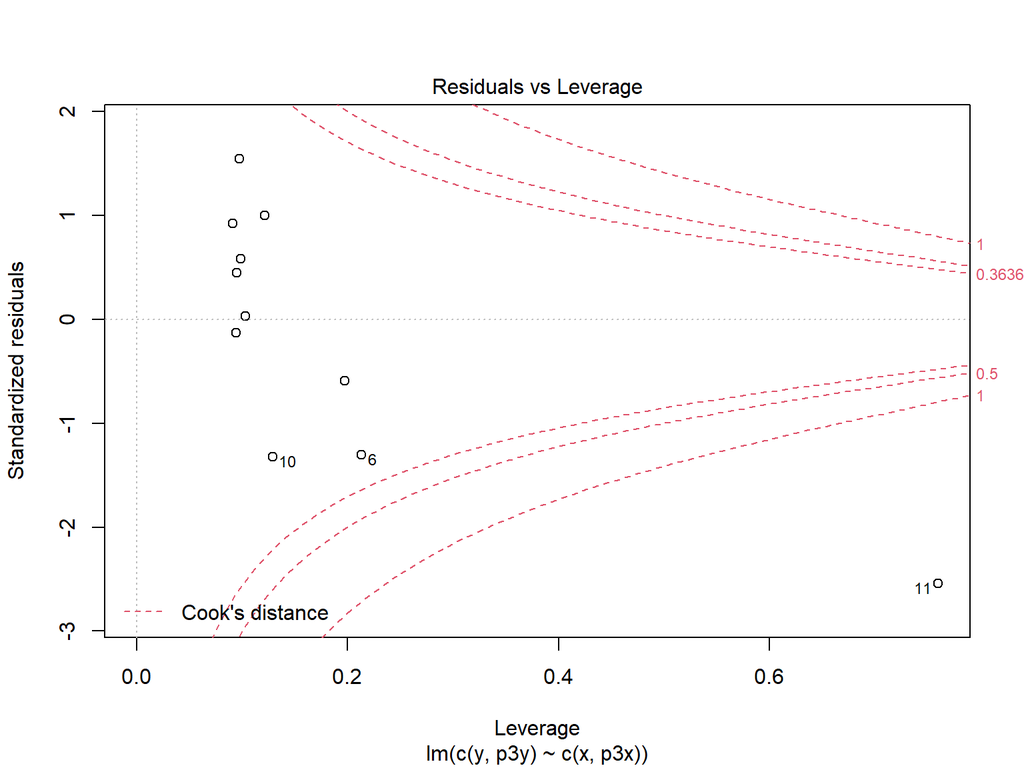

```r
plot(mod.3, which = 5, add.smooth = FALSE, cook.levels = c(4 / 11, 0.5, 1))
```